# Machine-Learning-vol.12-主成分分析ml122_17.1ml12_17.2漏れ不備

## 12.1 教師なし学習とは

**主成分分析（Principal Components Analysis, PCA）**とは､**与えられたデータを要約するような特徴量（主成分）を抽出する手法**です｡より数学的には､**特徴空間内の座標軸を再設定する手法**であるといえます｡**教師なし学習**のアルゴリズムのひとつであり､主に教師あり学習のための**前処理**に利用されます｡また､PCAは全体の情報をより有用な特徴量に縮約する**特徴抽出**の一手法であり､**次元削減**を容易にします｡これによって､**データの解釈がしやすくなったり（意味解釈性の向上）**､**モデルの性能が向上したり**といった効果が見込まれます｡

[figure not shown]

### 分析ストーリー : 植物の種分化研究④

アヤメの花の種分化を研究している植物学者は､学会での発表のために**データの意味解釈性を高めること**を検討していました｡研究の結果をより理解してもらいやすくするために､**データの表す意味を簡潔に説明すること**を目指したのです｡**データが表す形状の違いを少ない特徴量に落とし込みます**｡また､その取り組みを通して､**これまでに構築したモデルの精度を更に向上させること**にもしました｡

[figure not shown]

教師なし学習とは､**教師ラベルを必要としない学習**のことです｡教師あり学習が行っている**勾配降下法による学習ができない**ために将来の予測には向きませんが､**既知のデータの構造を理解するためには非常に有用です**｡教師あり学習を支援する**前処理**の手法として広く利用されています｡

[figure not shown]

### 12.1.1 既知のデータの構造を把握する

教師なし学習の最大の目的は､**既知のデータの構造を理解すること**であり､教師あり学習の未知のデータの持つ情報を予測することとは明確に区別されます｡これによって､**分析者がデータをより良く理解できるようになる**こと､あるいは**教師あり学習のモデルの性能を向上させること**が可能です｡例えば､主成分分析で求められた主成分はデータ全体を要約しており､分析者の理解を助けるとともに教師あり学習での**次元削減**を実現します｡一方､クラスタリングでは､類似性に基いてサンプルをいくつかの集団（クラスタ）に分割します｡

### 12.1.2 主観の混入

教師なし学習で最も注意すべきことは､**分析者の主観的な解釈が混入すること**です｡教師あり学習の場合は､testデータがモデルの出すべき正解を示してくれます｡しかし､**教師なし学習では結果が正解かどうかが客観的にはわかりません**｡分析者が意味づけに納得するかどうかだけが基準になります｡なので､**教師なし学習は判断の証拠として利用するべきではありません**｡

## 12.2 データの要約

主成分分析のコンセプトは**データの要約**です｡この節では､要約というものの意味と恩恵を正しく理解することを目指します｡

### 12.2.1 観測変数と潜在変数

観測変数とは**直接測ることができる変数**であるのに対し､潜在変数は**直接測ることができない変数**です｡潜在変数を知りたい場合､**観測変数の組み合わせによって表現する必要があります**｡たとえば､学生の**｢地頭の良さ｣**という潜在変数を知りたかったとします｡この場合は､学力テストを行うなどして**英数理社のテストの点数**を収集します｡テストの点数は観測変数であり､これを利用して地頭の良さを評価することになります｡たとえば､以下のような式で表現できるかもしれません｡

[figure not shown]

あるいは､**アンケート**などから**化粧品メーカーのブランドイメージ**などを知ることも出来るかもしれませんし､あるいは**健康診断の数値**データから**日常のストレスの度合い**などを知ることも出来るかもしれません｡こうすることでデータを解釈しやすくなり､かつ潜在変数を特徴量とした教師あり学習を行うことも出来るようになります｡データ分析における要約とは､このように**観測変数から潜在変数を合成すること**､あるいはそれによって**次元削減を行うこと**を指しています｡

[figure not shown]

### 12.2.2 次元削減の恩恵

データ分析において**次元削減**をする利点を3つ紹介します｡

#### ① 意味解釈性の向上

**データやモデルの意味を解釈するとき､それは次元が低いほど容易になります**｡たとえば､アイスコーヒーの売上個数を予測する回帰分析をするとき､**｢売上個数は､気温によって決まる｣**と言われたほうが**｢売上個数は､気温と曜日と店員が誰であるかといった要因が絡み合って決まる｣**と言われるよりも理解しやすくなります｡また､**可視化**などもしやすくなるため､意味的にだけでなく視覚的にも解釈がしやすくなります｡

[figure not shown]

#### ② 次元の呪いの回避

次元の呪いとは､**特徴空間が高次元になるにつれて過学習が起こりやすくなることです**｡これは､**高次元空間では人間の持つ3次元までの直感に反する現象が起きるため**です｡これによって分析が上手くいかなくなってしまうことが増えてしまうので､次元削減によってこれを回避することが必要になります｡

#### ③ 計算時間の削減

最後は､単純に計算時間の削減です｡扱うデータが少なくなればなるほど計算量がかからなくなります｡計算量が多いと､時間や費用がかさむことになるので､こうした現実的な問題を避けることができます｡

## 12.3 PCAのアルゴリズム

PCAは以下のようなアルゴリズムに従って行われます｡最終目的は､**観測変数のデータから潜在変数となる主成分を作り出すこと**です｡このとき､主成分は以下のような**合成ベクトル**で表されます｡

$$PC_i = h_1x_1 + h_2x_2 + ... + h_dx_d$$

1. データを**標準化**する（図①）
2. データの**重心**を求める（図②）
3. **重心を通る軸**で、**データの分散が最大となる方向に座標軸を設定する**（図③）
4. **既にとった軸と直交する方向の中で**､分散が最大となる方向に次の座標軸を設定する（図④）
5. **座標軸の数が､データの次元数と同じになるまで**､4を繰り返す

[figure not shown]

### 12.3.1 データの標準化

主成分分析では､**標準化の処理を必ず行わなければなりません**｡ばらつきを求める際に､**すべての変数について同じスケーリングで距離を測定する必要があるのです**｡

$$x^{(i)}_{std} = \frac{x^{(i)} - \mu_x}{\sigma_x}$$

$\mu_x : 特徴量の平均値$ , $\sigma_x : 特徴量の標準偏差$

[figure not shown]

### 12.3.2 データの重心を求める

次に､**データの重心を求めます**｡このとき､**すべての主成分の座標軸は､この重心を通るように設定されます**｡つまりは､**主成分空間における原点**を定めているのがこの工程です｡原点を定めることで､主成分空間における**線形性が保証されます（今まで通り､線形代数でものを考えられるようになります）**｡

[figure not shown]

### 12.3.3 ばらつきが最大である方向に軸を取る

次に､**重心を通る主成分をデータ点のばらつきが最大となる方向に定めます**｡このときに重要なのが､**"情報量 = ばらつき"** という考え方です｡回帰や分類などの教師あり学習は､**ばらつきを手がかりにモデルを学習させています**｡仮にばらつきがないとなると､**同じようなサンプルしか手元にない**ということになります｡**これではデータから法則性が浮かび上がってこなくなってしまう**ので､ばらつきが情報量と等価になっていたことに気付かされます｡よって､**主成分にはできるだけ大きなばらつきを拾わせるようにすべきなのです**｡ちなみに､重心に原点を重ねていることは､**主成分にばらつきを捉えやすくする工夫**でもあります｡

[figure not shown]

### 12.3.4 これまでに設定した座標軸と直交させる

**2本目以降の座標軸を設定するとき**は､重心を通ることに加えて､**これまでに設定した座標軸と直交させるという条件を付け加えます**｡これは､**新しい主成分に､これまでに設定した主成分が取りこぼした情報だけを拾わせること**が目的です｡このようにすれば､**新たな主成分に次々と効率よく情報を拾っていけるのです**｡

[figure not shown]

また､軸が直交するということは､**それぞれの主成分に相関がなくなる**ということを意味します｡成分間に相関があると､**多重共線性**などの問題が起こる原因になるので､これを取り除いておくことは後の分析に大きく役に立ちます｡

[figure not shown]

## 12.4 選択と抽出の比較

PCAでは上記のアルゴリズムに従って**特徴抽出**が行われますが､次元削減の方法には特徴抽出以外に**特徴選択**というものがあります｡この節では､実装をしながら両者の比較をします｡

[figure not shown]

#### 特徴選択

特徴選択とは､**もともとある特徴量の一部を選んでそのまま利用する方法**です｡**情報量**や**相関関係**を参考に学習に用いる特徴量を選択して学習させます｡**LASSO**や**ElasticNet**によって行われていたものも特徴選択です｡

#### 特徴抽出

特徴抽出とは､**データの特徴量全体から情報量の多い特徴量を新たに作り出す方法**です｡一般に､**特徴抽出の方が少ない特徴量で効率よくデータを表現できます**｡

### 12.4.1 特徴選択の実装

まずは特徴選択の実装をしていきます｡今回も**iris**のデータセットを利用して､SVMによる分類を行います｡

[figure not shown]

```python
# 必要なライブラリを読み込み
import numpy as np
import matplotlib.pyplot as plt
% matplotlib inline
```

```python
# irisデータのロード
from sklearn.datasets import load_iris
iris = load_iris()
X = iris.data
y = iris.target
```

```python
# データに含まれている特徴量を確認
feature_names = iris.feature_names

iris.feature_names
```

```
['sepal length (cm)',
 'sepal width (cm)',
 'petal length (cm)',
 'petal width (cm)']
```

```python
# Xを確認(１０個)

X[:10]
```

```
array([[ 5.1,  3.5,  1.4,  0.2],
       [ 4.9,  3. ,  1.4,  0.2],
       [ 4.7,  3.2,  1.3,  0.2],
       [ 4.6,  3.1,  1.5,  0.2],
       [ 5. ,  3.6,  1.4,  0.2],
       [ 5.4,  3.9,  1.7,  0.4],
       [ 4.6,  3.4,  1.4,  0.3],
       [ 5. ,  3.4,  1.5,  0.2],
       [ 4.4,  2.9,  1.4,  0.2],
       [ 4.9,  3.1,  1.5,  0.1]])
```

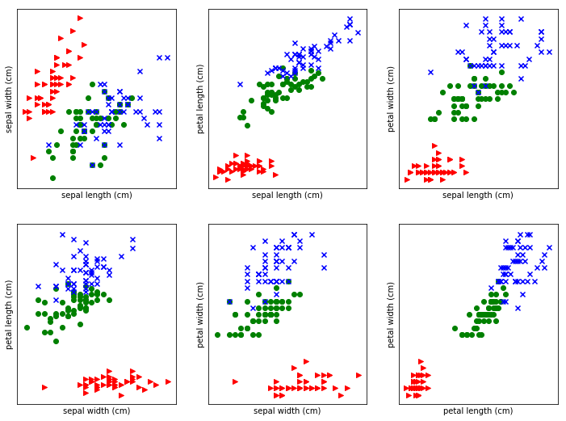

```python
# 特徴選択による可視化
# 4つの特徴量のうち､2つを選んで2次元にする
import matplotlib.pyplot as plt

# 4つの特徴量の組み合わせを定義（合計6通り）
# 0: sepal length
# 1: sepal width
# 2: petal length
# 3: petal width
pairs = [(0, 1), (0, 2), (0, 3), (1, 2), (1, 3), (2, 3)]

# 各組み合わせに対して散布図を表示
# グラフのサイズを指定
plt.figure(figsize=(12, 9))

# グラフを特徴量のpairごとに表示
# クラスラベルごとに色を分けてプロット
# 赤: setosa
# 青: versicolor
# 緑: verginica
for i, (p0, p1) in enumerate(pairs):
    plt.subplot(2, 3, i + 1)
    # クラスラベルごとに色分けしてプロット
    for target, marker, color in zip(list(range(3)), ">ox", "rgb"):
        plt.scatter(X[iris.target == target, p0], X[iris.target == target, p1], marker=marker, c=color)
    plt.xlabel(feature_names[p0])
    plt.ylabel(feature_names[p1])
    plt.xticks([])
    plt.yticks([])

plt.show()
```

### 12.4.2 特徴抽出の実装

次は､**PCA**を用いて**特徴抽出**を行います｡**sklearn**の**decomposition**の中にある､**PCAクラス**を利用して行います｡

[figure not shown]

```python
# データの標準化
from sklearn.preprocessing import StandardScaler
scaler = StandardScaler()
scaler.fit(X)                   # 与えられた行列の各特徴量について､平均と標準偏差を算出
X_std = scaler.fit_transform(X) # Xを標準化した行列を生成
```

```python
# 主成分分析を実行
from sklearn.decomposition import PCA
pca = PCA(n_components=4) # 主成分を4つまで取得
X_pca = pca.fit_transform(X_std)
```

```python
# 抽出した特徴量の値を出力(１０個)
X_pca[:10]
```

```
array([[-2.26454173,  0.5057039 , -0.12194335, -0.02307332],
       [-2.0864255 , -0.65540473, -0.22725083, -0.10320824],
       [-2.36795045, -0.31847731,  0.05147962, -0.02782523],
       [-2.30419716, -0.57536771,  0.09886044,  0.06631146],
       [-2.38877749,  0.6747674 ,  0.02142785,  0.03739729],
       [-2.07053681,  1.51854856,  0.03068426, -0.00439877],
       [-2.44571134,  0.07456268,  0.34219764,  0.03809657],
       [-2.23384186,  0.24761393, -0.08257446,  0.02550516],
       [-2.34195768, -1.09514636,  0.1535624 ,  0.02679383],
       [-2.18867576, -0.44862905, -0.24655952,  0.0399073 ]])
```

### 12.4.3 可視化による比較

寄与率の大きい順に2つの主成分を選んで（$PC_1$ と $PC_2$）可視化をしてみます｡これが､**irisのデータセットを要約した特徴空間**になっています｡

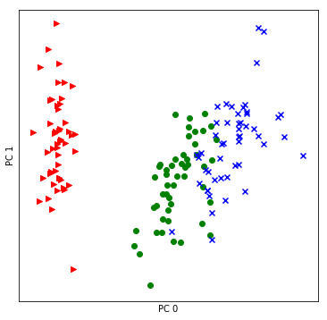

```python
# 特徴抽出による可視化
# PC0とPC1について散布図を表示
plt.figure(figsize=(6, 6))
for target, marker, color in zip(range(3), '>ox', 'rgb'):
    plt.scatter(X_pca[iris.target==target, 0], X_pca[iris.target==target, 1], marker=marker, color=color)
plt.xlabel('PC 0')
plt.ylabel('PC 1')
plt.xticks([])
plt.yticks([])
plt.show()
```

PCAの結果は以上のようになりました｡こちらが**irisのデータを要約した結果**です｡しかし､**特徴選択の場合のプロットと見比べてもそれほど大きな差異があるようには思えません**｡そこで､次節で**より厳密な数値での指標をもとに効果を検証します**｡

[figure not shown]

## 12.5 PCAの評価指標

PCAの結果を定量的に評価するために､**代表的な評価指標**について学びます｡今回取り扱うのは､以下の3つの指標です｡

1. 寄与率
2. 累積寄与率
3. 因子負荷量

### 12.5.1 寄与率

寄与率とは､**ひとつの主成分がデータ全体の情報をどれだけの割合拾えているか**を表す指標です｡数式的には､**各主成分の持つ固有値の比率**を表します｡固有値とは､線形代数に登場する $\lambda$ などの文字で表される指標です｡主成分分析においては､**この固有値が各主成分の持つ情報量を表す指標として利用できます**｡定義より､寄与率は**0~1**の値を取り､**その総和は1になります**｡**寄与率が高ければ高いほど､その主成分はデータを効率よく要約する良い主成分であるといえます**｡

[figure not shown]

```python
# 寄与率を出力
# 各主成分の寄与率がarrayの形式で入っている
# [第一主成分の寄与率 第二主成分の寄与率 ...]
print(pca.explained_variance_ratio_)
```

```
[ 0.72770452  0.23030523  0.03683832  0.00515193]
```

### 12.5.2 累積寄与率

累積寄与率とは､その名の通り**寄与率の累積値**であり､**これまでに採用した主成分すべてで拾えた情報が合計でどの程度になるか**を表す指標になります｡また､寄与率と累積寄与率は以下のような図で表現することができます｡**各主成分は互いに直行しているため､互いの拾う情報に重複がないところがポイントです**｡

[figure not shown]

#### 20:80の法則

20:80の法則（別名: パレートの法則）とは､**重要なものの80%は､全体の20%のものに集中する**という経験則です｡**捉えるべきは重要な少数（Vital Few）であり､些末な多数（Trivial Many）ではない**というコンセプトを持っており､主成分分析における**次元削減のヒント**を与えてくれます｡もともとは経済学における**｢収入の80%は､全体の20%の人に集中する｣**という発見から生まれましたが､このような不均衡は経済以外の様々な分野でも当てはまることが多かったため､データ分析含め広く一般に利用されています｡これに倣い､**累積寄与率も80%程度になるように少数の主成分の利用を抑えるべきだと言えます**｡寄与率の小さな主成分を加えていっても分析に対して貢献しないどころか､**むしろ次元の呪いや計算量の増加を引き起こしてしまい､分析に有用とは言えないのです**｡

[figure not shown]

```python
# 累積寄与率を出力
# np.cumsum()で固有値の累積をとる
# [第1主成分までの累積寄与率 第2主成分までの累積寄与率 ...]
print(np.cumsum(pca.explained_variance_ratio_))
```

```
[ 0.72770452  0.95800975  0.99484807  1.        ]
```

さて､80:20の法則によれば､**第3､第4主成分はほとんど分析に貢献しないものとされます**｡それが本当なのか､可視化をして確認してみましょう｡

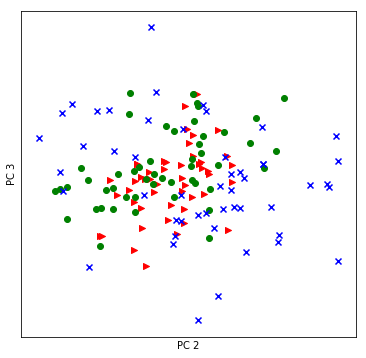

```python
# 特徴抽出による可視化
# PC3とPC4について散布図を表示
plt.figure(figsize=(6, 6))
for target, marker, color in zip(range(3), '>ox', 'rgb'):
    plt.scatter(X_pca[iris.target==target, 2], X_pca[iris.target==target, 3], marker=marker, color=color)
plt.xlabel('PC 2')
plt.ylabel('PC 3')
plt.xticks([])
plt.yticks([])
plt.show()
```

下に**上位の主成分との比較画像**を用意しました｡出力した結果､下位の主成分は目で見ても明らかに分類に貢献しなさそうなことがわかります｡それだけ､**上位の主成分が情報量を効率よく吸収していることがわかります**｡irisデータは4次元と低次元なデータなのでそれほど心配はいりませんが､**特徴量が多いデータになるほど次元削減を行うことの利益は大きくなります**｡

[figure not shown]

### 12.5.3 因子負荷量

因子負荷量（主成分負荷量）とは､**主成分がもとの特徴量をどのように合成して作られたものなのかを表す指標**です｡それぞれの主成分に対して､**もとの各特徴量との相関係数にあたる数値**が割り当てられており､**-1~+1**の値を取ります｡因子負荷量を参照することで､**導かれた主成分の意味付けを行うことができます**｡ひとつの主成分が､**どのような特徴量と相関が強いのか（軸が同じ向きや逆の向きになっているのか）**､あるいは**どのような特徴量とは相関がないのか（軸が直行しているかどうか）**に着目することで､主成分の表す意味が浮かび上がってきます｡

[figure not shown]

数式的には､**主成分に含まれる各特徴量の係数 $h_j$ に､その主成分の固有値 $l_i$ の平方根 $\sqrt{l_i}$ を掛け算して表現されます**｡重要なのは､ $h_j$ を利用して定義されていることから､**もともとの特徴量との相関が考慮されていること**が確認できることです｡

[figure not shown]

このようにして主成分に意味付けを行うことができれば､各サンプルを従来の特徴量の値ではなく**各主成分 $PC_i$ の値（主成分スコア）を用いて評価することができます**｡つまりは､**｢この学生は地頭がどの程度良いか？どれだけ理系寄りか？｣**であったり､**｢どれだけ体格ががっちりしているか？どれだけスレンダーか？｣**という評価の仕方が出来るのです｡

```python
# 主成分の係数h_jを出力
pca.components_
```

```
array([[ 0.52237162, -0.26335492,  0.58125401,  0.56561105],
       [ 0.37231836,  0.92555649,  0.02109478,  0.06541577],
       [-0.72101681,  0.24203288,  0.14089226,  0.6338014 ],
       [-0.26199559,  0.12413481,  0.80115427, -0.52354627]])
```

```python
# 固有値lのルートを取る
np.sqrt(pca.explained_variance_)
```

```
array([ 1.70611198,  0.95980255,  0.38386622,  0.14355385])
```

```python
# 因子負荷量を出力
# ['sepal length', 'sepal width', 'petal length', 'petal width']
pca.components_ * np.sqrt(pca.explained_variance_)[:, np.newaxis]
```

```
array([[ 0.89122448, -0.44931298,  0.99168442,  0.96499579],
       [ 0.35735211,  0.88835148,  0.02024682,  0.06278622],
       [-0.276774  ,  0.09290825,  0.05408378,  0.24329495],
       [-0.03761047,  0.01782003,  0.11500878, -0.07515708]])
```

#### irisデータの因子負荷量を解釈

この結果から､irisの第一主成分を解釈してみましょう｡irisデータでは第1主成分の寄与率が0.73近くもあるので､**かなり影響力の大きい特徴量**になっているといえます｡第1主成分の因子負荷量は､がく片の長さ､花びらの長さ､花びらの幅に対して**0.9近くの強い正の相関**があり､かつがく片の幅は**中程度の負の相関**を示しています｡つまり､アヤメの3品種の花は**｢いかに花びら大きく､かつがく片が細長い形になっているか｣**という基準で最もよく違いを観察できることになります｡

## 12.6 分類精度への貢献

これまでに利用してきた特徴選択とPCAによる特徴抽出を比較して､**分類精度をどれだけ上げるのか**を確認します｡両者において**交差検証**を行います｡

### 12.6.1 特徴選択の場合

まずは特徴選択です｡

```python
# PCA前のデータを確認
# 標準化をしたとこまでのデータを利用
X_std[:10]
```

```
array([[-0.90068117,  1.03205722, -1.3412724 , -1.31297673],
       [-1.14301691, -0.1249576 , -1.3412724 , -1.31297673],
       [-1.38535265,  0.33784833, -1.39813811, -1.31297673],
       [-1.50652052,  0.10644536, -1.2844067 , -1.31297673],
       [-1.02184904,  1.26346019, -1.3412724 , -1.31297673],
       [-0.53717756,  1.95766909, -1.17067529, -1.05003079],
       [-1.50652052,  0.80065426, -1.3412724 , -1.18150376],
       [-1.02184904,  0.80065426, -1.2844067 , -1.31297673],
       [-1.74885626, -0.35636057, -1.3412724 , -1.31297673],
       [-1.14301691,  0.10644536, -1.2844067 , -1.4444497 ]])
```

```python
# 特徴量選択のために､特徴量を確認
iris.feature_names
```

```
['sepal length (cm)',
 'sepal width (cm)',
 'petal length (cm)',
 'petal width (cm)']
```

```python
# 特徴選択(１０個)
X_std[:, 0:2][:10]
```

```
array([[-0.90068117,  1.03205722],
       [-1.14301691, -0.1249576 ],
       [-1.38535265,  0.33784833],
       [-1.50652052,  0.10644536],
       [-1.02184904,  1.26346019],
       [-0.53717756,  1.95766909],
       [-1.50652052,  0.80065426],
       [-1.02184904,  0.80065426],
       [-1.74885626, -0.35636057],
       [-1.14301691,  0.10644536]])
```

```python
# SVMで分類
from sklearn.svm import SVC
from sklearn.model_selection import cross_val_score
scores_1 = cross_val_score(SVC(), X_std[:, [0,2]], y, cv=5)
scores_1.mean()
```

```
0.94000000000000006
```

### 12.6.2 特徴抽出の場合

次に､**特徴抽出**を行って実行します｡こちらも同様に2つの特徴量を利用して行います｡

```python
# PCA後のデータを確認(１０個)

X_pca[:10]
```

```
array([[-2.26454173,  0.5057039 , -0.12194335, -0.02307332],
       [-2.0864255 , -0.65540473, -0.22725083, -0.10320824],
       [-2.36795045, -0.31847731,  0.05147962, -0.02782523],
       [-2.30419716, -0.57536771,  0.09886044,  0.06631146],
       [-2.38877749,  0.6747674 ,  0.02142785,  0.03739729],
       [-2.07053681,  1.51854856,  0.03068426, -0.00439877],
       [-2.44571134,  0.07456268,  0.34219764,  0.03809657],
       [-2.23384186,  0.24761393, -0.08257446,  0.02550516],
       [-2.34195768, -1.09514636,  0.1535624 ,  0.02679383],
       [-2.18867576, -0.44862905, -0.24655952,  0.0399073 ]])
```

```python
# 第2主成分までを選択(１０個)

X_pca[:, 0:2][:10]
```

```
array([[-2.26454173,  0.5057039 ],
       [-2.0864255 , -0.65540473],
       [-2.36795045, -0.31847731],
       [-2.30419716, -0.57536771],
       [-2.38877749,  0.6747674 ],
       [-2.07053681,  1.51854856],
       [-2.44571134,  0.07456268],
       [-2.23384186,  0.24761393],
       [-2.34195768, -1.09514636],
       [-2.18867576, -0.44862905]])
```

```python
# SVMで分類
from sklearn.svm import SVC
from sklearn.model_selection import cross_val_score
scores_2 = cross_val_score(SVC(), X_pca[:, [0,2]], y, cv=5)
scores_2.mean()
```

```
0.95999999999999996
```

両者を比較すると､特徴抽出の方が2%ほど性能が高いことがわかります｡

```python
# 両者の精度を比較
print('特徴選択: {}'.format(scores_1.mean()))
print('特徴抽出: {}'.format(scores_2.mean()))
```

```
特徴選択: 0.9400000000000001
特徴抽出: 0.96
```

[figure not shown]

監修: 東京女子大学情報処理センター 浅川伸一